# RNA-seq differential-expression analysis

This report performs RNA-seq sample assessment, DESeq2 differential-expression analysis and exports significant genes sets for further analysis.

The Results section begins with an Overview tab that summarises the report-level signals, after which the remaining tabs break the analysis into method- or evidence-specific views and downloads.

# Results

## Overview

This overview condenses the RNA-seq quality-control and differential-expression outputs into a small set of report-entry signals. Use it to identify which contexts contributed the largest candidate sets, whether pairwise overlap is substantial, and whether the sample-level QC layer is populated as expected before reading the detailed tabs.

### Key Statistics

**RNA-seq contexts**  
2

**Samples profiled**  
12

**Largest DE candidate set**  
3480  
HT29

**Largest shared overlap**  
238  
HT29 / Sw480

**RNA biotype annotations**  
78457

**Housekeeping genes cached**  
8813

### Input data

This table lists the core input files used to generate the RNA-seq quality-control and differential-expression results. `Exists` confirms that the file was available at render time, while `Rows`, `Columns` and `Size (KB)` provide a quick sanity check on the loaded data objects.

| Role | File | Description | Exists | Rows | Columns | Size (KB) |
| --- | --- | --- | --- | --- | --- | --- |
| Input | salmon.merged.gene_counts.tsv | Salmon merged gene-count table used for DESeq2 and sample QC | TRUE | 78457 | 14 | 5161.4 |
| Input | hpa_housekeeping_genes.tsv | Cached Human Protein Atlas housekeeping gene list used for housekeeping-expression QC | TRUE | 8813 | 3 | 347.4 |
| Input | Homo_sapiens.GRCh38.115.gtf.gz | Cached Ensembl release-115 GTF used to fill RNA-biotype annotations for sample composition | TRUE |  |  | 101948.8 |
| Input | experimental_samplesheet.tsv | Experimental samplesheet defining RNA-seq samples and contrasts | TRUE | 28 | 14 | 4.3 |

## Sample quality

This section checks sample-level RNA-seq quality metrics for each manifest-defined context before interpretation of differential expression.

### Summary

This tab summarises the RNA-seq quality-control inputs and provides downloads for the sample-level metrics and RNA-type composition table. The cards report the number of samples per manifest-defined context, the number of annotation rows available for RNA-type classification, and the number of cached Human Protein Atlas housekeeping genes used for the housekeeping-expression check.

**HT29 samples**  
6

**Sw480 samples**  
6

**Annotation rows**  
78457

**HPA housekeeping genes cached**  
8813

Download sample QC metrics CSV Download sample RNA composition CSV

### HT29

This tab contains sample-quality views for the HT29 RNA-seq context. Use these plots together to identify unusual library sizes, composition shifts, broad expression differences, or sample separation that should be considered before interpreting differential-expression results.

#### PCA

These principal-component views summarise the largest expression differences between samples using variance-stabilised counts. PCA is an exploratory quality-assessment tool: separation may reflect the intended experimental contrast, technical variation, or other sample metadata.

##### Scores

This selectable two-dimensional PCA score plot places samples according to the chosen principal components. Samples that cluster together have more similar global expression profiles; use the component selectors to inspect separation beyond PC1 and PC2.

[interactive chart not shown]

##### Scree plot

This scree plot shows the percentage of variance explained by each principal component. Components with larger bars account for more of the sample-to-sample expression variation and are the most useful starting points for interpreting the PCA score plot.

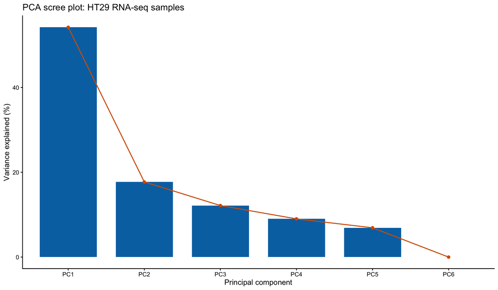

##### Metadata associations

This heatmap tests exploratory associations between principal components and available sample metadata fields. Stronger colour intensity indicates a stronger association; use these results to identify whether major expression axes track the intended condition or a possible technical covariate.

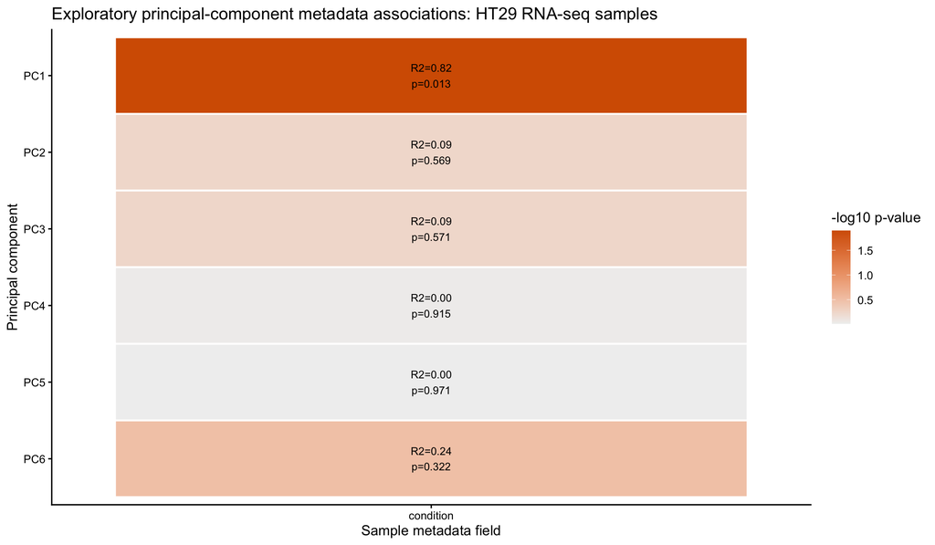

#### Library size

This bar chart reports the total mapped gene counts for each sample. Large differences in library size can affect sensitivity and should be reviewed alongside the other quality-control plots, although DESeq2 normalisation accounts for sequencing-depth differences during differential-expression modelling.

[interactive chart not shown]

#### Sample composition

This stacked bar chart shows the percentage contribution of RNA biotypes within each sample, including mitochondrial RNA, ribosomal RNA, tRNA, miRNA, other small non-coding RNA, mRNA, lncRNA, pseudogene and residual categories where annotation is available. Samples with visibly different composition profiles may require closer review.

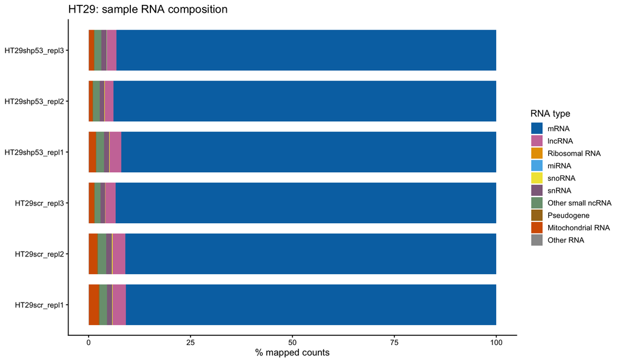

#### Housekeeping expression

This bar chart reports the percentage of expression assigned to cached Human Protein Atlas housekeeping genes. It provides a broad composition check rather than a pass-or-fail threshold; unexpectedly different values may indicate sample-quality or composition differences.

[interactive chart not shown]

#### Genes expressed

This bar chart reports the percentage of annotated genes with at least 10 counts in each sample. Lower values indicate that fewer genes were detectably expressed and may reflect library complexity, sequencing depth, or biological composition.

[interactive chart not shown]

### Sw480

This tab contains sample-quality views for the Sw480 RNA-seq context. Use these plots together to identify unusual library sizes, composition shifts, broad expression differences, or sample separation that should be considered before interpreting differential-expression results.

#### PCA

These principal-component views summarise the largest expression differences between samples using variance-stabilised counts. PCA is an exploratory quality-assessment tool: separation may reflect the intended experimental contrast, technical variation, or other sample metadata.

##### Scores

This selectable two-dimensional PCA score plot places samples according to the chosen principal components. Samples that cluster together have more similar global expression profiles; use the component selectors to inspect separation beyond PC1 and PC2.

[interactive chart not shown]

##### Scree plot

This scree plot shows the percentage of variance explained by each principal component. Components with larger bars account for more of the sample-to-sample expression variation and are the most useful starting points for interpreting the PCA score plot.

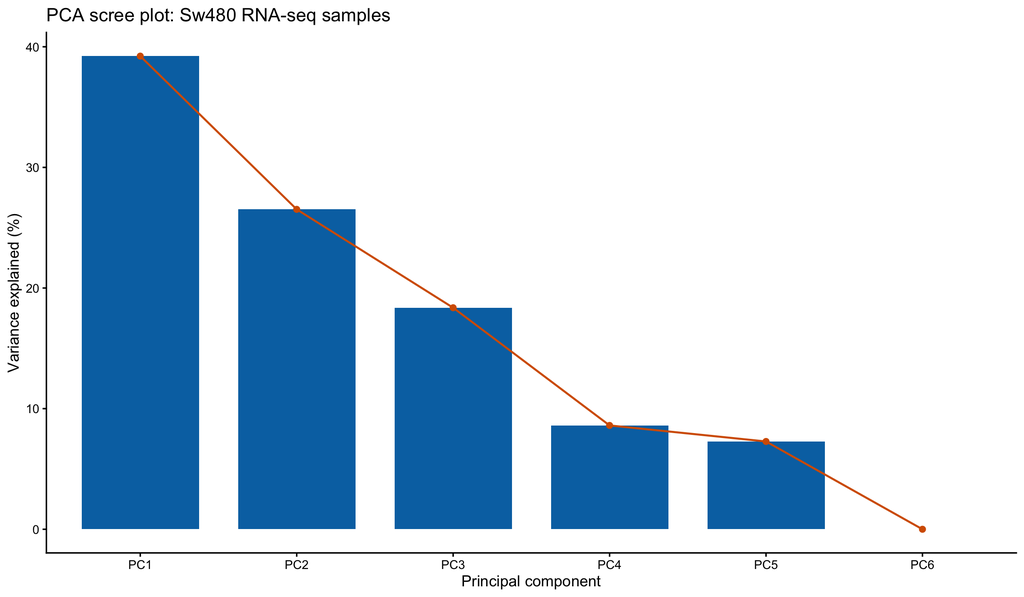

##### Metadata associations

This heatmap tests exploratory associations between principal components and available sample metadata fields. Stronger colour intensity indicates a stronger association; use these results to identify whether major expression axes track the intended condition or a possible technical covariate.

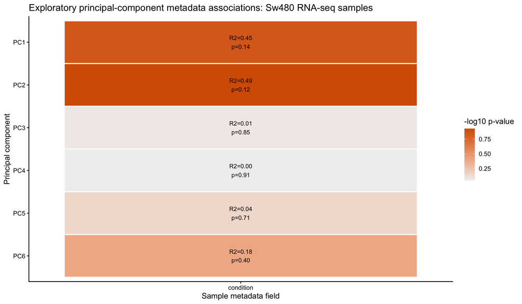

#### Library size

This bar chart reports the total mapped gene counts for each sample. Large differences in library size can affect sensitivity and should be reviewed alongside the other quality-control plots, although DESeq2 normalisation accounts for sequencing-depth differences during differential-expression modelling.

[interactive chart not shown]

#### Sample composition

This stacked bar chart shows the percentage contribution of RNA biotypes within each sample, including mitochondrial RNA, ribosomal RNA, tRNA, miRNA, other small non-coding RNA, mRNA, lncRNA, pseudogene and residual categories where annotation is available. Samples with visibly different composition profiles may require closer review.

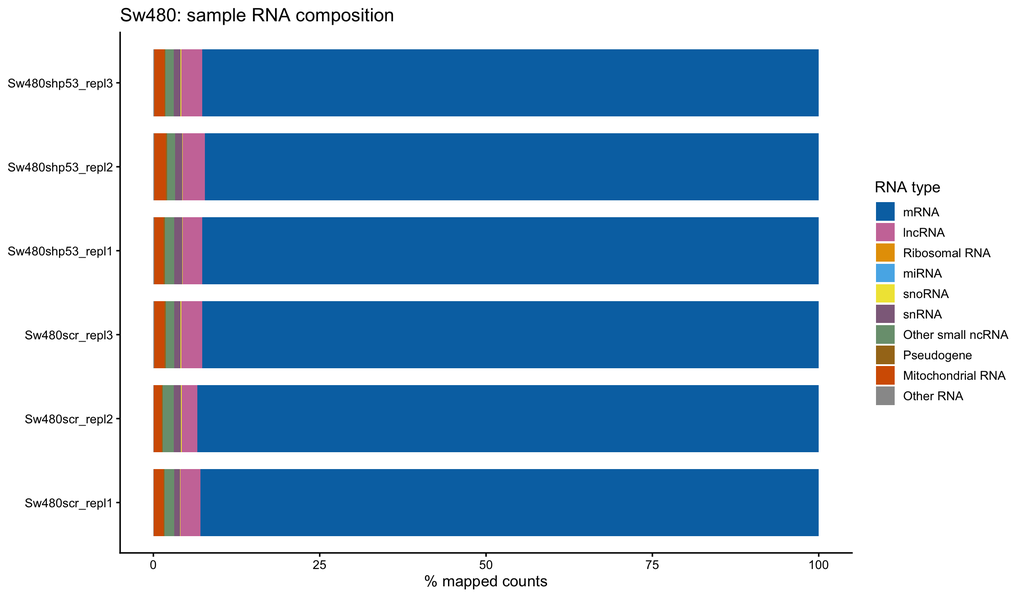

#### Housekeeping expression

This bar chart reports the percentage of expression assigned to cached Human Protein Atlas housekeeping genes. It provides a broad composition check rather than a pass-or-fail threshold; unexpectedly different values may indicate sample-quality or composition differences.

[interactive chart not shown]

#### Genes expressed

This bar chart reports the percentage of annotated genes with at least 10 counts in each sample. Lower values indicate that fewer genes were detectably expressed and may reflect library complexity, sequencing depth, or biological composition.

[interactive chart not shown]

## Differential expression

This section reports DESeq2 results for every manifest-defined RNA-seq contrast. Pairwise consensus tabs are generated automatically when two or more contexts are configured.

**HT29 DE candidates**  
3480

**Sw480 DE candidates**  
855

Download HT29 DESeq2 results CSV Download Sw480 DESeq2 results CSV Download HT29 DE candidate genes CSV Download Sw480 DE candidate genes CSV Download HT29 / Sw480 consensus CSV

### Pairwise consensus

This tab compares every pair of manifest-defined RNA-seq contexts. The summary and overlap diagram use genes passing the configured differential-expression thresholds in each context, while the pairwise PCA uses all retained genes shared by the two count matrices so that sample separation is not biased toward significant candidates.

#### HT29 / Sw480

This comparison brings together the HT29 and Sw480 differential-expression analyses. Use the summary table to review genes significant in both contexts, the Venn diagram to inspect overlap, and the PCA tabs to assess all-sample structure across both contexts.

##### Summary

This summary reports the number of DE candidates in HT29, the number in Sw480, and the shared set. The preview table lists up to 50 shared genes with Ensembl identifier, gene name, description, log2 fold-change, raw p-value and adjusted p-value for both contexts; the CSV download contains the complete shared set.

**HT29 DE candidates**  
3480

**Sw480 DE candidates**  
855

**Shared DE candidates**  
238

Download HT29 / Sw480 consensus CSV

Top 50 shared DE candidates: HT29 / Sw480

| gene_ID | Gene_Name | Gene_Description | FC_HT29 | Pval_HT29 | Adj Pval_HT29 | FC_Sw480 | Pval_Sw480 | Adj Pval_Sw480 |
| --- | --- | --- | --- | --- | --- | --- | --- | --- |
| ENSG00000006118 | [TMEM132A](https://www.ensembl.org/Homo_sapiens/Gene/Summary?g=ENSG00000006118) | transmembrane protein 132A [Source:HGNC Symbol;Acc:HGNC:31092] | -0.6680607 | 0.0000000 | 0.0000000 | -0.4862423 | 0.0000017 | 0.0001315 |
| ENSG00000006530 | [AGK](https://www.ensembl.org/Homo_sapiens/Gene/Summary?g=ENSG00000006530) | acylglycerol kinase [Source:HGNC Symbol;Acc:HGNC:21869] | -0.2665391 | 0.0005396 | 0.0052336 | -0.2942948 | 0.0007915 | 0.0220435 |
| ENSG00000011260 | [UTP18](https://www.ensembl.org/Homo_sapiens/Gene/Summary?g=ENSG00000011260) | UTP18 small subunit processome component [Source:HGNC Symbol;Acc:HGNC:24274] | 0.2208827 | 0.0039070 | 0.0231607 | -0.2734029 | 0.0010865 | 0.0281442 |
| ENSG00000014216 | [CAPN1](https://www.ensembl.org/Homo_sapiens/Gene/Summary?g=ENSG00000014216) | calpain 1 [Source:HGNC Symbol;Acc:HGNC:1476] | 0.3841216 | 0.0000002 | 0.0000082 | 0.3634337 | 0.0000211 | 0.0011862 |
| ENSG00000040275 | [SPDL1](https://www.ensembl.org/Homo_sapiens/Gene/Summary?g=ENSG00000040275) | spindle apparatus coiled-coil protein 1 [Source:HGNC Symbol;Acc:HGNC:26010] | -0.5653195 | 0.0000000 | 0.0000000 | -0.4180552 | 0.0000014 | 0.0001144 |
| ENSG00000041982 | [TNC](https://www.ensembl.org/Homo_sapiens/Gene/Summary?g=ENSG00000041982) | tenascin C [Source:HGNC Symbol;Acc:HGNC:5318] | -1.3363309 | 0.0000000 | 0.0000000 | 0.8005414 | 0.0000000 | 0.0000015 |
| ENSG00000049246 | [PER3](https://www.ensembl.org/Homo_sapiens/Gene/Summary?g=ENSG00000049246) | period circadian regulator 3 [Source:HGNC Symbol;Acc:HGNC:8847] | 0.2888029 | 0.0050225 | 0.0279249 | 0.4872259 | 0.0000000 | 0.0000045 |
| ENSG00000051108 | [HERPUD1](https://www.ensembl.org/Homo_sapiens/Gene/Summary?g=ENSG00000051108) | homocysteine inducible ER protein with ubiquitin like domain 1 [Source:HGNC Symbol;Acc:HGNC:13744] | 0.4195963 | 0.0000023 | 0.0000655 | 0.2512253 | 0.0013045 | 0.0321694 |
| ENSG00000052795 | [FNIP2](https://www.ensembl.org/Homo_sapiens/Gene/Summary?g=ENSG00000052795) | folliculin interacting protein 2 [Source:HGNC Symbol;Acc:HGNC:29280] | 0.3681284 | 0.0000000 | 0.0000012 | 0.4792904 | 0.0000005 | 0.0000460 |
| ENSG00000057019 | [DCBLD2](https://www.ensembl.org/Homo_sapiens/Gene/Summary?g=ENSG00000057019) | discoidin, CUB and LCCL domain containing 2 [Source:HGNC Symbol;Acc:HGNC:24627] | -0.2896422 | 0.0038198 | 0.0227575 | -0.5330282 | 0.0006967 | 0.0199410 |
| ENSG00000058668 | [ATP2B4](https://www.ensembl.org/Homo_sapiens/Gene/Summary?g=ENSG00000058668) | ATPase plasma membrane Ca2+ transporting 4 [Source:HGNC Symbol;Acc:HGNC:817] | 0.4898547 | 0.0000000 | 0.0000002 | -0.3885398 | 0.0002232 | 0.0082027 |
| ENSG00000062038 | [CDH3](https://www.ensembl.org/Homo_sapiens/Gene/Summary?g=ENSG00000062038) | cadherin 3 [Source:HGNC Symbol;Acc:HGNC:1762] | 0.6351359 | 0.0000242 | 0.0004345 | 1.1681956 | 0.0000003 | 0.0000274 |
| ENSG00000065457 | [ADAT1](https://www.ensembl.org/Homo_sapiens/Gene/Summary?g=ENSG00000065457) | adenosine deaminase tRNA specific 1 [Source:HGNC Symbol;Acc:HGNC:228] | -0.4695970 | 0.0000000 | 0.0000000 | -0.3693501 | 0.0000028 | 0.0002115 |
| ENSG00000065534 | [MYLK](https://www.ensembl.org/Homo_sapiens/Gene/Summary?g=ENSG00000065534) | myosin light chain kinase [Source:HGNC Symbol;Acc:HGNC:7590] | -0.5854945 | 0.0000000 | 0.0000000 | -0.5638699 | 0.0001765 | 0.0067733 |
| ENSG00000066468 | [FGFR2](https://www.ensembl.org/Homo_sapiens/Gene/Summary?g=ENSG00000066468) | fibroblast growth factor receptor 2 [Source:HGNC Symbol;Acc:HGNC:3689] | -0.3901471 | 0.0000047 | 0.0001188 | 0.6835953 | 0.0006924 | 0.0198511 |
| ENSG00000068650 | [ATP11A](https://www.ensembl.org/Homo_sapiens/Gene/Summary?g=ENSG00000068650) | ATPase phospholipid transporting 11A [Source:HGNC Symbol;Acc:HGNC:13552] | 0.3449751 | 0.0000001 | 0.0000039 | 0.5558473 | 0.0000003 | 0.0000337 |
| ENSG00000070367 | [EXOC5](https://www.ensembl.org/Homo_sapiens/Gene/Summary?g=ENSG00000070367) | exocyst complex component 5 [Source:HGNC Symbol;Acc:HGNC:10696] | 0.5625909 | 0.0000000 | 0.0000000 | 0.3867996 | 0.0000981 | 0.0043697 |
| ENSG00000076356 | [PLXNA2](https://www.ensembl.org/Homo_sapiens/Gene/Summary?g=ENSG00000076356) | plexin A2 [Source:HGNC Symbol;Acc:HGNC:9100] | 0.2159583 | 0.0069074 | 0.0354524 | 1.2422652 | 0.0009059 | 0.0244821 |
| ENSG00000077514 | [POLD3](https://www.ensembl.org/Homo_sapiens/Gene/Summary?g=ENSG00000077514) | DNA polymerase delta 3, accessory subunit [Source:HGNC Symbol;Acc:HGNC:20932] | -0.3205420 | 0.0000528 | 0.0008284 | -0.3571645 | 0.0003924 | 0.0128045 |
| ENSG00000078401 | [EDN1](https://www.ensembl.org/Homo_sapiens/Gene/Summary?g=ENSG00000078401) | endothelin 1 [Source:HGNC Symbol;Acc:HGNC:3176] | 0.3641158 | 0.0000463 | 0.0007392 | -0.4796970 | 0.0006603 | 0.0191492 |
| ENSG00000080839 | [RBL1](https://www.ensembl.org/Homo_sapiens/Gene/Summary?g=ENSG00000080839) | RB transcriptional corepressor like 1 [Source:HGNC Symbol;Acc:HGNC:9893] | -0.3661127 | 0.0000003 | 0.0000099 | -0.2690225 | 0.0015698 | 0.0367878 |
| ENSG00000082146 | [STRADB](https://www.ensembl.org/Homo_sapiens/Gene/Summary?g=ENSG00000082146) | STE20 related adaptor beta [Source:HGNC Symbol;Acc:HGNC:13205] | -0.3485717 | 0.0088719 | 0.0423894 | -0.5629809 | 0.0000000 | 0.0000012 |
| ENSG00000083123 | [BCKDHB](https://www.ensembl.org/Homo_sapiens/Gene/Summary?g=ENSG00000083123) | branched chain keto acid dehydrogenase E1 subunit beta [Source:HGNC Symbol;Acc:HGNC:987] | -0.5579063 | 0.0000000 | 0.0000000 | -0.2860551 | 0.0004341 | 0.0138570 |
| ENSG00000085741 | [WNT11](https://www.ensembl.org/Homo_sapiens/Gene/Summary?g=ENSG00000085741) | Wnt family member 11 [Source:HGNC Symbol;Acc:HGNC:12776] | 0.4961373 | 0.0034984 | 0.0213686 | 0.7911145 | 0.0000067 | 0.0004432 |
| ENSG00000088035 | [ALG6](https://www.ensembl.org/Homo_sapiens/Gene/Summary?g=ENSG00000088035) | ALG6 alpha-1,3-glucosyltransferase [Source:HGNC Symbol;Acc:HGNC:23157] | -0.4399536 | 0.0000178 | 0.0003421 | -0.2912468 | 0.0012007 | 0.0302197 |
| ENSG00000088970 | [KIZ](https://www.ensembl.org/Homo_sapiens/Gene/Summary?g=ENSG00000088970) | kizuna centrosomal protein [Source:HGNC Symbol;Acc:HGNC:15865] | -0.5975420 | 0.0000000 | 0.0000004 | 0.3394428 | 0.0001013 | 0.0044304 |
| ENSG00000095321 | [CRAT](https://www.ensembl.org/Homo_sapiens/Gene/Summary?g=ENSG00000095321) | carnitine O-acetyltransferase [Source:HGNC Symbol;Acc:HGNC:2342] | 0.2654663 | 0.0038161 | 0.0227439 | 0.3294245 | 0.0006598 | 0.0191492 |
| ENSG00000096696 | [DSP](https://www.ensembl.org/Homo_sapiens/Gene/Summary?g=ENSG00000096696) | desmoplakin [Source:HGNC Symbol;Acc:HGNC:3052] | 0.3469989 | 0.0000026 | 0.0000705 | 0.2674918 | 0.0003871 | 0.0126791 |
| ENSG00000100311 | [PDGFB](https://www.ensembl.org/Homo_sapiens/Gene/Summary?g=ENSG00000100311) | platelet derived growth factor subunit B [Source:HGNC Symbol;Acc:HGNC:8800] | 0.3722408 | 0.0003844 | 0.0040477 | 0.3398427 | 0.0010671 | 0.0278894 |
| ENSG00000100379 | [KCTD17](https://www.ensembl.org/Homo_sapiens/Gene/Summary?g=ENSG00000100379) | potassium channel tetramerization domain containing 17 [Source:HGNC Symbol;Acc:HGNC:25705] | -0.8521859 | 0.0001142 | 0.0015323 | -0.4487650 | 0.0012642 | 0.0315771 |
| ENSG00000101076 | [HNF4A](https://www.ensembl.org/Homo_sapiens/Gene/Summary?g=ENSG00000101076) | hepatocyte nuclear factor 4 alpha [Source:HGNC Symbol;Acc:HGNC:5024] | 0.3983388 | 0.0000001 | 0.0000046 | 0.6637364 | 0.0000000 | 0.0000003 |
| ENSG00000101096 | [NFATC2](https://www.ensembl.org/Homo_sapiens/Gene/Summary?g=ENSG00000101096) | nuclear factor of activated T cells 2 [Source:HGNC Symbol;Acc:HGNC:7776] | -0.4754368 | 0.0016391 | 0.0122714 | -0.3976559 | 0.0010998 | 0.0283191 |
| ENSG00000101213 | [PTK6](https://www.ensembl.org/Homo_sapiens/Gene/Summary?g=ENSG00000101213) | protein tyrosine kinase 6 [Source:HGNC Symbol;Acc:HGNC:9617] | 0.2367677 | 0.0028933 | 0.0185045 | 0.5311891 | 0.0000058 | 0.0003933 |
| ENSG00000101346 | [POFUT1](https://www.ensembl.org/Homo_sapiens/Gene/Summary?g=ENSG00000101346) | protein O-fucosyltransferase 1 [Source:HGNC Symbol;Acc:HGNC:14988] | -0.4916792 | 0.0000000 | 0.0000000 | -0.5011845 | 0.0000019 | 0.0001500 |
| ENSG00000101384 | [JAG1](https://www.ensembl.org/Homo_sapiens/Gene/Summary?g=ENSG00000101384) | jagged canonical Notch ligand 1 [Source:HGNC Symbol;Acc:HGNC:6188] | 0.8662270 | 0.0000000 | 0.0000000 | 0.5709814 | 0.0000009 | 0.0000759 |
| ENSG00000101752 | [MIB1](https://www.ensembl.org/Homo_sapiens/Gene/Summary?g=ENSG00000101752) | MIB E3 ubiquitin protein ligase 1 [Source:HGNC Symbol;Acc:HGNC:21086] | -0.9285705 | 0.0000000 | 0.0000000 | -0.6285803 | 0.0000000 | 0.0000000 |
| ENSG00000101928 | [MOSPD1](https://www.ensembl.org/Homo_sapiens/Gene/Summary?g=ENSG00000101928) | motile sperm domain containing 1 [Source:HGNC Symbol;Acc:HGNC:25235] | -0.3833386 | 0.0007567 | 0.0068251 | -0.7752017 | 0.0000000 | 0.0000000 |
| ENSG00000102547 | [CAB39L](https://www.ensembl.org/Homo_sapiens/Gene/Summary?g=ENSG00000102547) | calcium binding protein 39 like [Source:HGNC Symbol;Acc:HGNC:20290] | 0.3635830 | 0.0009880 | 0.0083857 | 0.5370596 | 0.0002866 | 0.0099457 |
| ENSG00000103257 | [SLC7A5](https://www.ensembl.org/Homo_sapiens/Gene/Summary?g=ENSG00000103257) | solute carrier family 7 member 5 [Source:HGNC Symbol;Acc:HGNC:11063] | 0.6311114 | 0.0000000 | 0.0000000 | 0.3463357 | 0.0000747 | 0.0034673 |
| ENSG00000103888 | [CEMIP](https://www.ensembl.org/Homo_sapiens/Gene/Summary?g=ENSG00000103888) | cell migration inducing hyaluronidase 1 [Source:HGNC Symbol;Acc:HGNC:29213] | 0.2883298 | 0.0002797 | 0.0031457 | 1.6407368 | 0.0000000 | 0.0000000 |
| ENSG00000104472 | [CHRAC1](https://www.ensembl.org/Homo_sapiens/Gene/Summary?g=ENSG00000104472) | chromatin accessibility complex subunit 1 [Source:HGNC Symbol;Acc:HGNC:13544] | 0.5656280 | 0.0000000 | 0.0000000 | 0.3604988 | 0.0005456 | 0.0167112 |
| ENSG00000105289 | [TJP3](https://www.ensembl.org/Homo_sapiens/Gene/Summary?g=ENSG00000105289) | tight junction protein 3 [Source:HGNC Symbol;Acc:HGNC:11829] | 0.3641679 | 0.0000030 | 0.0000810 | 0.6083187 | 0.0000725 | 0.0034015 |
| ENSG00000105810 | [CDK6](https://www.ensembl.org/Homo_sapiens/Gene/Summary?g=ENSG00000105810) | cyclin dependent kinase 6 [Source:HGNC Symbol;Acc:HGNC:1777] | 0.5007626 | 0.0000000 | 0.0000000 | 0.4543818 | 0.0000021 | 0.0001605 |
| ENSG00000105963 | [ADAP1](https://www.ensembl.org/Homo_sapiens/Gene/Summary?g=ENSG00000105963) | ArfGAP with dual PH domains 1 [Source:HGNC Symbol;Acc:HGNC:16486] | 0.3307636 | 0.0000540 | 0.0008461 | 0.4199654 | 0.0010840 | 0.0281200 |
| ENSG00000106078 | [COBL](https://www.ensembl.org/Homo_sapiens/Gene/Summary?g=ENSG00000106078) | cordon-bleu WH2 repeat protein [Source:HGNC Symbol;Acc:HGNC:22199] | 0.8305380 | 0.0001861 | 0.0023088 | 0.3684610 | 0.0003121 | 0.0106020 |
| ENSG00000106123 | [EPHB6](https://www.ensembl.org/Homo_sapiens/Gene/Summary?g=ENSG00000106123) | EPH receptor B6 [Source:HGNC Symbol;Acc:HGNC:3396] | 0.3432367 | 0.0104228 | 0.0474537 | 0.9261658 | 0.0000000 | 0.0000000 |
| ENSG00000106366 | [SERPINE1](https://www.ensembl.org/Homo_sapiens/Gene/Summary?g=ENSG00000106366) | serpin family E member 1 [Source:HGNC Symbol;Acc:HGNC:8583] | -0.7850863 | 0.0018985 | 0.0136782 | -0.9273508 | 0.0000000 | 0.0000000 |
| ENSG00000106546 | [AHR](https://www.ensembl.org/Homo_sapiens/Gene/Summary?g=ENSG00000106546) | aryl hydrocarbon receptor [Source:HGNC Symbol;Acc:HGNC:348] | 0.4217688 | 0.0000000 | 0.0000003 | 0.4671661 | 0.0000021 | 0.0001633 |
| ENSG00000106683 | [LIMK1](https://www.ensembl.org/Homo_sapiens/Gene/Summary?g=ENSG00000106683) | LIM domain kinase 1 [Source:HGNC Symbol;Acc:HGNC:6613] | -1.1108551 | 0.0000000 | 0.0000000 | -0.7120744 | 0.0000000 | 0.0000001 |
| ENSG00000106785 | [TRIM14](https://www.ensembl.org/Homo_sapiens/Gene/Summary?g=ENSG00000106785) | tripartite motif containing 14 [Source:HGNC Symbol;Acc:HGNC:16283] | 0.3728185 | 0.0000013 | 0.0000403 | -0.2902563 | 0.0007059 | 0.0201376 |

##### Venn

This Venn diagram shows the overlap between thresholded DE candidate genes from the two contexts. The non-overlapping regions are context-specific candidates and the intersection is the shared consensus set.

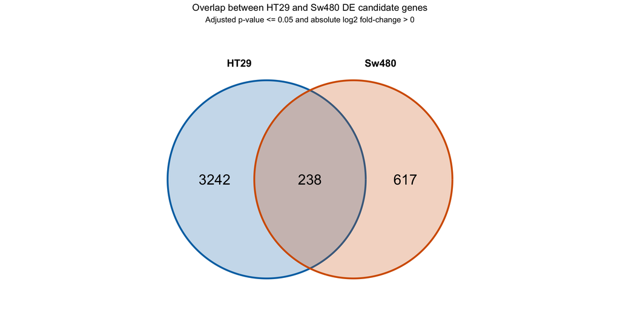

##### PCA

These pairwise PCA views use all retained genes shared by the two context-specific count matrices and include samples from both contexts. They provide an unbiased exploratory view of whether samples separate by context, experimental condition, or another metadata field.

###### Scores

This selectable PCA score plot places all samples from the two contexts according to the selected principal components. Relative position reflects global expression similarity across all retained shared genes.

[interactive chart not shown]

###### Scree plot

This scree plot reports how much pairwise sample variance is explained by each principal component. Use it to identify which component pairs are most informative in the selectable score plot.

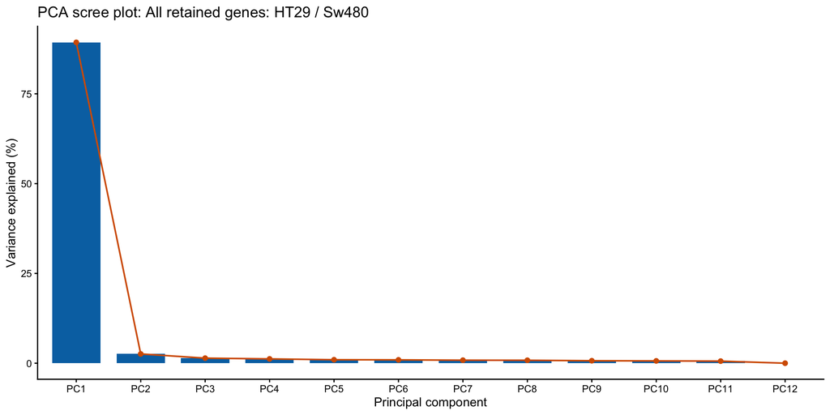

###### Metadata associations

This heatmap reports exploratory associations between pairwise PCA components and the combined sample metadata. It helps distinguish intended condition effects from context or technical effects.

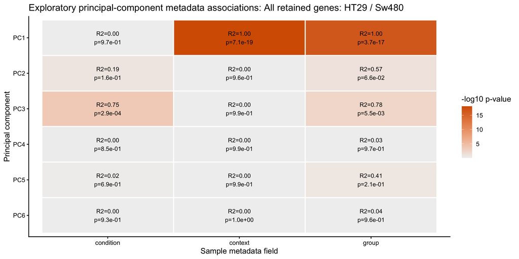

### HT29

This tab contains the differential-expression results for the HT29 context. Candidate genes pass the global adjusted p-value threshold and absolute log2 fold-change threshold; plots provide complementary views of effect size, significance and expression pattern.

#### Summary

This summary reports the number of tested genes and thresholded DE candidates. The preview table lists up to 50 candidates with Ensembl identifier, gene name, gene description, log2 fold-change, raw p-value and adjusted p-value; the linked CSV contains the complete candidate set.

**HT29 tested genes**  
15490

**HT29 DE candidates**  
3480

Download HT29 DE candidate genes CSV

Top 50 HT29 DE candidates

| gene_ID | Gene_Name | Gene_Description | FC | Pval | Adj Pval |
| --- | --- | --- | --- | --- | --- |
| ENSG00000000003 | [TSPAN6](https://www.ensembl.org/Homo_sapiens/Gene/Summary?g=ENSG00000000003) | tetraspanin 6 [Source:HGNC Symbol;Acc:HGNC:11858] | -0.5388236 | 0.0000000 | 0.0000003 |
| ENSG00000000971 | [CFH](https://www.ensembl.org/Homo_sapiens/Gene/Summary?g=ENSG00000000971) | complement factor H [Source:HGNC Symbol;Acc:HGNC:4883] | -0.5887510 | 0.0000000 | 0.0000000 |
| ENSG00000001036 | [FUCA2](https://www.ensembl.org/Homo_sapiens/Gene/Summary?g=ENSG00000001036) | alpha-L-fucosidase 2 [Source:HGNC Symbol;Acc:HGNC:4008] | 0.1987514 | 0.0086658 | 0.0417995 |
| ENSG00000001084 | [GCLC](https://www.ensembl.org/Homo_sapiens/Gene/Summary?g=ENSG00000001084) | glutamate-cysteine ligase catalytic subunit [Source:HGNC Symbol;Acc:HGNC:4311] | 0.5211591 | 0.0000000 | 0.0000001 |
| ENSG00000001461 | [NIPAL3](https://www.ensembl.org/Homo_sapiens/Gene/Summary?g=ENSG00000001461) | NIPA like domain containing 3 [Source:HGNC Symbol;Acc:HGNC:25233] | 0.1811576 | 0.0111157 | 0.0496201 |
| ENSG00000001561 | [ENPP4](https://www.ensembl.org/Homo_sapiens/Gene/Summary?g=ENSG00000001561) | ectonucleotide pyrophosphatase/phosphodiesterase 4 [Source:HGNC Symbol;Acc:HGNC:3359] | 0.2273537 | 0.0071835 | 0.0364838 |
| ENSG00000001626 | [CFTR](https://www.ensembl.org/Homo_sapiens/Gene/Summary?g=ENSG00000001626) | CF transmembrane conductance regulator [Source:HGNC Symbol;Acc:HGNC:1884] | 0.2526980 | 0.0021782 | 0.0151369 |
| ENSG00000001630 | [CYP51A1](https://www.ensembl.org/Homo_sapiens/Gene/Summary?g=ENSG00000001630) | cytochrome P450 family 51 subfamily A member 1 [Source:HGNC Symbol;Acc:HGNC:2649] | 0.5685404 | 0.0022239 | 0.0154063 |
| ENSG00000002919 | [SNX11](https://www.ensembl.org/Homo_sapiens/Gene/Summary?g=ENSG00000002919) | sorting nexin 11 [Source:HGNC Symbol;Acc:HGNC:14975] | 0.2706795 | 0.0017285 | 0.0127779 |
| ENSG00000003436 | [TFPI](https://www.ensembl.org/Homo_sapiens/Gene/Summary?g=ENSG00000003436) | tissue factor pathway inhibitor [Source:HGNC Symbol;Acc:HGNC:11760] | -0.3130502 | 0.0000061 | 0.0001464 |
| ENSG00000003756 | [RBM5](https://www.ensembl.org/Homo_sapiens/Gene/Summary?g=ENSG00000003756) | RNA binding motif protein 5 [Source:HGNC Symbol;Acc:HGNC:9902] | -0.2317134 | 0.0108335 | 0.0486830 |
| ENSG00000004399 | [PLXND1](https://www.ensembl.org/Homo_sapiens/Gene/Summary?g=ENSG00000004399) | plexin D1 [Source:HGNC Symbol;Acc:HGNC:9107] | -0.2382323 | 0.0022897 | 0.0157337 |
| ENSG00000004478 | [FKBP4](https://www.ensembl.org/Homo_sapiens/Gene/Summary?g=ENSG00000004478) | FKBP prolyl isomerase 4 [Source:HGNC Symbol;Acc:HGNC:3720] | 0.3783726 | 0.0000360 | 0.0005999 |
| ENSG00000004487 | [KDM1A](https://www.ensembl.org/Homo_sapiens/Gene/Summary?g=ENSG00000004487) | lysine demethylase 1A [Source:HGNC Symbol;Acc:HGNC:29079] | -0.1592328 | 0.0110137 | 0.0492785 |
| ENSG00000004777 | [ARHGAP33](https://www.ensembl.org/Homo_sapiens/Gene/Summary?g=ENSG00000004777) | Rho GTPase activating protein 33 [Source:HGNC Symbol;Acc:HGNC:23085] | -0.5757322 | 0.0012494 | 0.0099729 |
| ENSG00000004779 | [NDUFAB1](https://www.ensembl.org/Homo_sapiens/Gene/Summary?g=ENSG00000004779) | NADH:ubiquinone oxidoreductase subunit AB1 [Source:HGNC Symbol;Acc:HGNC:7694] | 0.3007463 | 0.0001274 | 0.0016682 |
| ENSG00000004961 | [HCCS](https://www.ensembl.org/Homo_sapiens/Gene/Summary?g=ENSG00000004961) | holocytochrome c synthase [Source:HGNC Symbol;Acc:HGNC:4837] | 0.2892866 | 0.0035188 | 0.0214534 |
| ENSG00000005007 | [UPF1](https://www.ensembl.org/Homo_sapiens/Gene/Summary?g=ENSG00000005007) | UPF1 RNA helicase and ATPase [Source:HGNC Symbol;Acc:HGNC:9962] | 0.1742350 | 0.0099622 | 0.0459498 |
| ENSG00000005022 | [SLC25A5](https://www.ensembl.org/Homo_sapiens/Gene/Summary?g=ENSG00000005022) | solute carrier family 25 member 5 [Source:HGNC Symbol;Acc:HGNC:10991] | 0.3248778 | 0.0002029 | 0.0024712 |
| ENSG00000005189 | [REXO5](https://www.ensembl.org/Homo_sapiens/Gene/Summary?g=ENSG00000005189) | RNA exonuclease 5 [Source:HGNC Symbol;Acc:HGNC:24661] | 0.2991424 | 0.0090884 | 0.0430651 |
| ENSG00000005206 | [SPPL2B](https://www.ensembl.org/Homo_sapiens/Gene/Summary?g=ENSG00000005206) | signal peptide peptidase like 2B [Source:HGNC Symbol;Acc:HGNC:30627] | -0.4515732 | 0.0000007 | 0.0000221 |
| ENSG00000005238 | [ATOSB](https://www.ensembl.org/Homo_sapiens/Gene/Summary?g=ENSG00000005238) | atos homolog B [Source:HGNC Symbol;Acc:HGNC:25666] | 0.2939703 | 0.0009424 | 0.0080915 |
| ENSG00000005379 | [TSPOAP1](https://www.ensembl.org/Homo_sapiens/Gene/Summary?g=ENSG00000005379) | TSPO associated protein 1 [Source:HGNC Symbol;Acc:HGNC:16831] | -0.7645548 | 0.0083651 | 0.0406575 |
| ENSG00000005448 | [WDR54](https://www.ensembl.org/Homo_sapiens/Gene/Summary?g=ENSG00000005448) | WD repeat domain 54 [Source:HGNC Symbol;Acc:HGNC:25770] | -0.5144013 | 0.0000193 | 0.0003628 |
| ENSG00000005513 | [SOX8](https://www.ensembl.org/Homo_sapiens/Gene/Summary?g=ENSG00000005513) | SRY-box transcription factor 8 [Source:HGNC Symbol;Acc:HGNC:11203] | 1.0067033 | 0.0007007 | 0.0064378 |
| ENSG00000005812 | [FBXL3](https://www.ensembl.org/Homo_sapiens/Gene/Summary?g=ENSG00000005812) | F-box and leucine rich repeat protein 3 [Source:HGNC Symbol;Acc:HGNC:13599] | 0.1917629 | 0.0049766 | 0.0277493 |
| ENSG00000005884 | [ITGA3](https://www.ensembl.org/Homo_sapiens/Gene/Summary?g=ENSG00000005884) | integrin subunit alpha 3 [Source:HGNC Symbol;Acc:HGNC:6139] | 0.2434353 | 0.0034119 | 0.0209227 |
| ENSG00000005893 | [LAMP2](https://www.ensembl.org/Homo_sapiens/Gene/Summary?g=ENSG00000005893) | lysosomal associated membrane protein 2 [Source:HGNC Symbol;Acc:HGNC:6501] | 0.2359673 | 0.0004389 | 0.0044605 |
| ENSG00000006047 | [YBX2](https://www.ensembl.org/Homo_sapiens/Gene/Summary?g=ENSG00000006047) | Y-box binding protein 2 [Source:HGNC Symbol;Acc:HGNC:17948] | 0.5736781 | 0.0013268 | 0.0104378 |
| ENSG00000006118 | [TMEM132A](https://www.ensembl.org/Homo_sapiens/Gene/Summary?g=ENSG00000006118) | transmembrane protein 132A [Source:HGNC Symbol;Acc:HGNC:31092] | -0.6680607 | 0.0000000 | 0.0000000 |
| ENSG00000006194 | [ZNF263](https://www.ensembl.org/Homo_sapiens/Gene/Summary?g=ENSG00000006194) | zinc finger protein 263 [Source:HGNC Symbol;Acc:HGNC:13056] | 0.1887755 | 0.0101843 | 0.0467005 |
| ENSG00000006282 | [SPATA20](https://www.ensembl.org/Homo_sapiens/Gene/Summary?g=ENSG00000006282) | spermatogenesis associated 20 [Source:HGNC Symbol;Acc:HGNC:26125] | -0.3542797 | 0.0000939 | 0.0013260 |
| ENSG00000006451 | [RALA](https://www.ensembl.org/Homo_sapiens/Gene/Summary?g=ENSG00000006451) | RAS like proto-oncogene A [Source:HGNC Symbol;Acc:HGNC:9839] | 0.2895519 | 0.0000426 | 0.0006891 |
| ENSG00000006468 | [ETV1](https://www.ensembl.org/Homo_sapiens/Gene/Summary?g=ENSG00000006468) | ETS variant transcription factor 1 [Source:HGNC Symbol;Acc:HGNC:3490] | -0.4123224 | 0.0006757 | 0.0062560 |
| ENSG00000006530 | [AGK](https://www.ensembl.org/Homo_sapiens/Gene/Summary?g=ENSG00000006530) | acylglycerol kinase [Source:HGNC Symbol;Acc:HGNC:21869] | -0.2665391 | 0.0005396 | 0.0052336 |
| ENSG00000006534 | [ALDH3B1](https://www.ensembl.org/Homo_sapiens/Gene/Summary?g=ENSG00000006534) | aldehyde dehydrogenase 3 family member B1 [Source:HGNC Symbol;Acc:HGNC:410] | 0.4322597 | 0.0000000 | 0.0000023 |
| ENSG00000006555 | [TTC22](https://www.ensembl.org/Homo_sapiens/Gene/Summary?g=ENSG00000006555) | tetratricopeptide repeat domain 22 [Source:HGNC Symbol;Acc:HGNC:26067] | 0.2602498 | 0.0015050 | 0.0114940 |
| ENSG00000006695 | [COX10](https://www.ensembl.org/Homo_sapiens/Gene/Summary?g=ENSG00000006695) | cytochrome c oxidase assembly factor heme A:farnesyltransferase COX10 [Source:HGNC Symbol;Acc:HGNC:2260] | 0.2455269 | 0.0033117 | 0.0204863 |
| ENSG00000006744 | [ELAC2](https://www.ensembl.org/Homo_sapiens/Gene/Summary?g=ENSG00000006744) | elaC ribonuclease Z 2 [Source:HGNC Symbol;Acc:HGNC:14198] | 0.1936510 | 0.0098083 | 0.0454068 |
| ENSG00000006747 | [SCIN](https://www.ensembl.org/Homo_sapiens/Gene/Summary?g=ENSG00000006747) | scinderin [Source:HGNC Symbol;Acc:HGNC:21695] | 0.7262783 | 0.0000100 | 0.0002170 |
| ENSG00000006756 | [ARSD](https://www.ensembl.org/Homo_sapiens/Gene/Summary?g=ENSG00000006756) | arylsulfatase D [Source:HGNC Symbol;Acc:HGNC:717] | 0.2609312 | 0.0008551 | 0.0075305 |
| ENSG00000006831 | [ADIPOR2](https://www.ensembl.org/Homo_sapiens/Gene/Summary?g=ENSG00000006831) | adiponectin receptor 2 [Source:HGNC Symbol;Acc:HGNC:24041] | 0.2658444 | 0.0001926 | 0.0023710 |
| ENSG00000007080 | [CCDC124](https://www.ensembl.org/Homo_sapiens/Gene/Summary?g=ENSG00000007080) | coiled-coil domain containing 124 [Source:HGNC Symbol;Acc:HGNC:25171] | 0.2217890 | 0.0098605 | 0.0455801 |
| ENSG00000007255 | [TRAPPC6A](https://www.ensembl.org/Homo_sapiens/Gene/Summary?g=ENSG00000007255) | trafficking protein particle complex subunit 6A [Source:HGNC Symbol;Acc:HGNC:23069] | 0.5597950 | 0.0000016 | 0.0000469 |
| ENSG00000007306 | [CEACAM7](https://www.ensembl.org/Homo_sapiens/Gene/Summary?g=ENSG00000007306) | CEA cell adhesion molecule 7 [Source:HGNC Symbol;Acc:HGNC:1819] | 0.8856194 | 0.0022599 | 0.0155925 |
| ENSG00000007376 | [RPUSD1](https://www.ensembl.org/Homo_sapiens/Gene/Summary?g=ENSG00000007376) | RNA pseudouridine synthase domain containing 1 [Source:HGNC Symbol;Acc:HGNC:14173] | 0.2825276 | 0.0011551 | 0.0094241 |
| ENSG00000007384 | [RHBDF1](https://www.ensembl.org/Homo_sapiens/Gene/Summary?g=ENSG00000007384) | rhomboid 5 homolog 1 [Source:HGNC Symbol;Acc:HGNC:20561] | -0.2924140 | 0.0000062 | 0.0001493 |
| ENSG00000007392 | [LUC7L](https://www.ensembl.org/Homo_sapiens/Gene/Summary?g=ENSG00000007392) | LUC7 like [Source:HGNC Symbol;Acc:HGNC:6723] | -0.3070338 | 0.0020327 | 0.0143581 |
| ENSG00000007516 | [BAIAP3](https://www.ensembl.org/Homo_sapiens/Gene/Summary?g=ENSG00000007516) | BAI1 associated protein 3 [Source:HGNC Symbol;Acc:HGNC:948] | -0.9870642 | 0.0000000 | 0.0000000 |
| ENSG00000007968 | [E2F2](https://www.ensembl.org/Homo_sapiens/Gene/Summary?g=ENSG00000007968) | E2F transcription factor 2 [Source:HGNC Symbol;Acc:HGNC:3114] | 0.3550528 | 0.0002558 | 0.0029413 |

#### MA plot

This MA plot compares mean normalised expression on the x-axis with log2 fold-change on the y-axis. It is useful for seeing whether large expression changes are concentrated among low-abundance genes and for identifying the overall balance of up- and down-regulation.

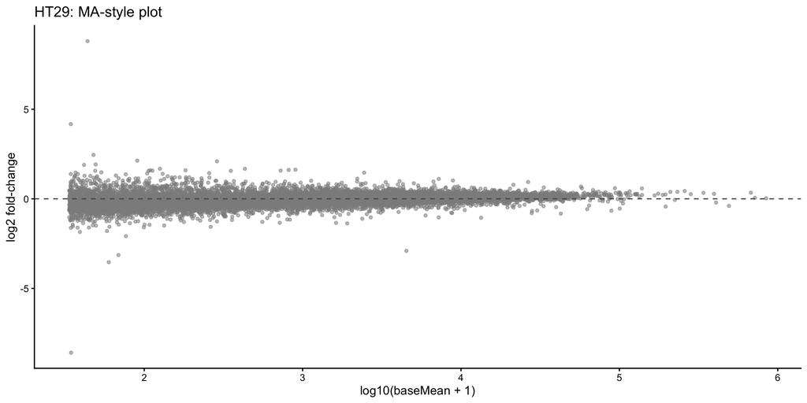

#### Volcano plot

This volcano plot compares log2 fold-change on the x-axis with statistical evidence on the y-axis. Genes farther from zero have larger effects and genes higher on the plot have stronger evidence; colour identifies genes passing the configured candidate thresholds.

[interactive chart not shown]

#### PCA

These context-specific PCA views summarise variance-stabilised gene expression across the samples used in this DESeq2 contrast. Use them to confirm sample structure and inspect whether major variance axes align with experimental metadata.

##### Scores

This selectable two-dimensional PCA score plot places samples according to the chosen components. Nearby samples have more similar expression profiles.

[interactive chart not shown]

##### Scree plot

This scree plot reports the variance explained by each principal component. The highest bars indicate the components carrying the largest expression differences between samples.

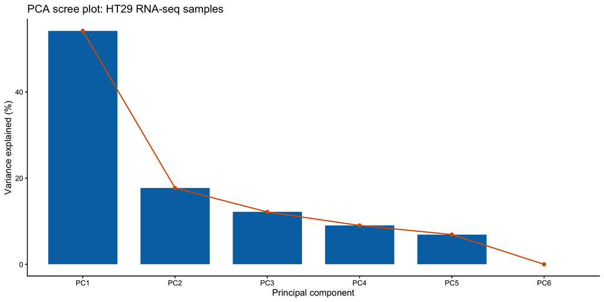

##### Metadata associations

This heatmap reports exploratory associations between PCA components and sample metadata. It should be used to guide interpretation and possible follow-up modelling, not as a standalone inferential result.

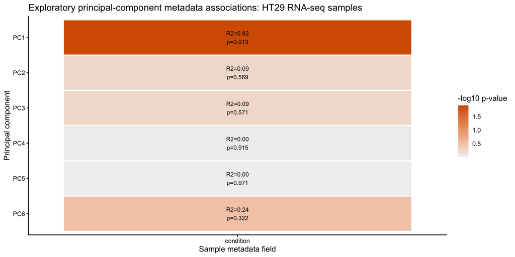

#### Heatmap by adjusted p-value

This heatmap displays up to 50 genes with the smallest adjusted p-values using variance-stabilised expression values. Rows are genes and columns are samples; clustering highlights expression patterns among the statistically strongest candidates.

[interactive chart not shown]

#### Heatmap by absolute log2 fold-change

This heatmap displays up to 50 genes with the largest absolute log2 fold-changes using variance-stabilised expression values. It emphasises the strongest effect sizes, which may differ from the genes with the smallest adjusted p-values.

[interactive chart not shown]

### Sw480

This tab contains the differential-expression results for the Sw480 context. Candidate genes pass the global adjusted p-value threshold and absolute log2 fold-change threshold; plots provide complementary views of effect size, significance and expression pattern.

#### Summary

This summary reports the number of tested genes and thresholded DE candidates. The preview table lists up to 50 candidates with Ensembl identifier, gene name, gene description, log2 fold-change, raw p-value and adjusted p-value; the linked CSV contains the complete candidate set.

**Sw480 tested genes**  
17459

**Sw480 DE candidates**  
855

Download Sw480 DE candidate genes CSV

Top 50 Sw480 DE candidates

| gene_ID | Gene_Name | Gene_Description | FC | Pval | Adj Pval |
| --- | --- | --- | --- | --- | --- |
| ENSG00000001617 | [SEMA3F](https://www.ensembl.org/Homo_sapiens/Gene/Summary?g=ENSG00000001617) | semaphorin 3F [Source:HGNC Symbol;Acc:HGNC:10728] | 1.1007245 | 0.0002586 | 0.0092580 |
| ENSG00000002586 | [CD99](https://www.ensembl.org/Homo_sapiens/Gene/Summary?g=ENSG00000002586) | CD99 molecule (Xg blood group) [Source:HGNC Symbol;Acc:HGNC:7082] | 0.2734843 | 0.0013836 | 0.0333189 |
| ENSG00000002587 | [HS3ST1](https://www.ensembl.org/Homo_sapiens/Gene/Summary?g=ENSG00000002587) | heparan sulfate-glucosamine 3-sulfotransferase 1 [Source:HGNC Symbol;Acc:HGNC:5194] | 1.3838552 | 0.0003214 | 0.0108534 |
| ENSG00000002745 | [WNT16](https://www.ensembl.org/Homo_sapiens/Gene/Summary?g=ENSG00000002745) | Wnt family member 16 [Source:HGNC Symbol;Acc:HGNC:16267] | 0.9363925 | 0.0010150 | 0.0267284 |
| ENSG00000003989 | [SLC7A2](https://www.ensembl.org/Homo_sapiens/Gene/Summary?g=ENSG00000003989) | solute carrier family 7 member 2 [Source:HGNC Symbol;Acc:HGNC:11060] | -0.5139580 | 0.0000000 | 0.0000044 |
| ENSG00000005020 | [SKAP2](https://www.ensembl.org/Homo_sapiens/Gene/Summary?g=ENSG00000005020) | src kinase associated phosphoprotein 2 [Source:HGNC Symbol;Acc:HGNC:15687] | 0.2701167 | 0.0001979 | 0.0074321 |
| ENSG00000005100 | [DHX33](https://www.ensembl.org/Homo_sapiens/Gene/Summary?g=ENSG00000005100) | DEAH-box helicase 33 [Source:HGNC Symbol;Acc:HGNC:16718] | -0.2375981 | 0.0004429 | 0.0140841 |
| ENSG00000005249 | [PRKAR2B](https://www.ensembl.org/Homo_sapiens/Gene/Summary?g=ENSG00000005249) | protein kinase cAMP-dependent type II regulatory subunit beta [Source:HGNC Symbol;Acc:HGNC:9392] | -0.7757036 | 0.0000283 | 0.0015322 |
| ENSG00000005471 | [ABCB4](https://www.ensembl.org/Homo_sapiens/Gene/Summary?g=ENSG00000005471) | ATP binding cassette subfamily B member 4 [Source:HGNC Symbol;Acc:HGNC:45] | 0.3732645 | 0.0001502 | 0.0060341 |
| ENSG00000006071 | [ABCC8](https://www.ensembl.org/Homo_sapiens/Gene/Summary?g=ENSG00000006071) | ATP binding cassette subfamily C member 8 [Source:HGNC Symbol;Acc:HGNC:59] | 0.9235132 | 0.0000184 | 0.0010542 |
| ENSG00000006118 | [TMEM132A](https://www.ensembl.org/Homo_sapiens/Gene/Summary?g=ENSG00000006118) | transmembrane protein 132A [Source:HGNC Symbol;Acc:HGNC:31092] | -0.4862423 | 0.0000017 | 0.0001315 |
| ENSG00000006327 | [TNFRSF12A](https://www.ensembl.org/Homo_sapiens/Gene/Summary?g=ENSG00000006327) | TNF receptor superfamily member 12A [Source:HGNC Symbol;Acc:HGNC:18152] | -0.3639700 | 0.0013797 | 0.0332717 |
| ENSG00000006459 | [KDM7A](https://www.ensembl.org/Homo_sapiens/Gene/Summary?g=ENSG00000006459) | lysine demethylase 7A [Source:HGNC Symbol;Acc:HGNC:22224] | 0.3526320 | 0.0001403 | 0.0057356 |
| ENSG00000006530 | [AGK](https://www.ensembl.org/Homo_sapiens/Gene/Summary?g=ENSG00000006530) | acylglycerol kinase [Source:HGNC Symbol;Acc:HGNC:21869] | -0.2942948 | 0.0007915 | 0.0220435 |
| ENSG00000007171 | [NOS2](https://www.ensembl.org/Homo_sapiens/Gene/Summary?g=ENSG00000007171) | nitric oxide synthase 2 [Source:HGNC Symbol;Acc:HGNC:7873] | 1.0287246 | 0.0000000 | 0.0000000 |
| ENSG00000011260 | [UTP18](https://www.ensembl.org/Homo_sapiens/Gene/Summary?g=ENSG00000011260) | UTP18 small subunit processome component [Source:HGNC Symbol;Acc:HGNC:24274] | -0.2734029 | 0.0010865 | 0.0281442 |
| ENSG00000011677 | [GABRA3](https://www.ensembl.org/Homo_sapiens/Gene/Summary?g=ENSG00000011677) | gamma-aminobutyric acid type A receptor subunit alpha3 [Source:HGNC Symbol;Acc:HGNC:4077] | 0.8865275 | 0.0000173 | 0.0010014 |
| ENSG00000012048 | [BRCA1](https://www.ensembl.org/Homo_sapiens/Gene/Summary?g=ENSG00000012048) | BRCA1 DNA repair associated [Source:HGNC Symbol;Acc:HGNC:1100] | -0.2446910 | 0.0003085 | 0.0105396 |
| ENSG00000013297 | [CLDN11](https://www.ensembl.org/Homo_sapiens/Gene/Summary?g=ENSG00000013297) | claudin 11 [Source:HGNC Symbol;Acc:HGNC:8514] | 0.3919001 | 0.0002734 | 0.0095836 |
| ENSG00000013588 | [GPRC5A](https://www.ensembl.org/Homo_sapiens/Gene/Summary?g=ENSG00000013588) | G protein-coupled receptor class C group 5 member A [Source:HGNC Symbol;Acc:HGNC:9836] | -0.7445602 | 0.0000016 | 0.0001275 |
| ENSG00000014216 | [CAPN1](https://www.ensembl.org/Homo_sapiens/Gene/Summary?g=ENSG00000014216) | calpain 1 [Source:HGNC Symbol;Acc:HGNC:1476] | 0.3634337 | 0.0000211 | 0.0011862 |
| ENSG00000016402 | [IL20RA](https://www.ensembl.org/Homo_sapiens/Gene/Summary?g=ENSG00000016402) | interleukin 20 receptor subunit alpha [Source:HGNC Symbol;Acc:HGNC:6003] | 0.9915994 | 0.0000158 | 0.0009270 |
| ENSG00000018236 | [CNTN1](https://www.ensembl.org/Homo_sapiens/Gene/Summary?g=ENSG00000018236) | contactin 1 [Source:HGNC Symbol;Acc:HGNC:2171] | 0.8174094 | 0.0021492 | 0.0459174 |
| ENSG00000019186 | [CYP24A1](https://www.ensembl.org/Homo_sapiens/Gene/Summary?g=ENSG00000019186) | cytochrome P450 family 24 subfamily A member 1 [Source:HGNC Symbol;Acc:HGNC:2602] | -0.7221776 | 0.0005107 | 0.0158372 |
| ENSG00000020633 | [RUNX3](https://www.ensembl.org/Homo_sapiens/Gene/Summary?g=ENSG00000020633) | RUNX family transcription factor 3 [Source:HGNC Symbol;Acc:HGNC:10473] | 0.6866337 | 0.0000000 | 0.0000006 |
| ENSG00000033627 | [ATP6V0A1](https://www.ensembl.org/Homo_sapiens/Gene/Summary?g=ENSG00000033627) | ATPase H+ transporting V0 subunit a1 [Source:HGNC Symbol;Acc:HGNC:865] | 0.2426800 | 0.0014585 | 0.0348355 |
| ENSG00000035687 | [ADSS2](https://www.ensembl.org/Homo_sapiens/Gene/Summary?g=ENSG00000035687) | adenylosuccinate synthase 2 [Source:HGNC Symbol;Acc:HGNC:292] | -0.2296516 | 0.0021869 | 0.0463918 |
| ENSG00000038210 | [PI4K2B](https://www.ensembl.org/Homo_sapiens/Gene/Summary?g=ENSG00000038210) | phosphatidylinositol 4-kinase type 2 beta [Source:HGNC Symbol;Acc:HGNC:18215] | -0.2484583 | 0.0020269 | 0.0439605 |
| ENSG00000039560 | [RAI14](https://www.ensembl.org/Homo_sapiens/Gene/Summary?g=ENSG00000039560) | retinoic acid induced 14 [Source:HGNC Symbol;Acc:HGNC:14873] | -0.2560279 | 0.0013133 | 0.0322951 |
| ENSG00000040275 | [SPDL1](https://www.ensembl.org/Homo_sapiens/Gene/Summary?g=ENSG00000040275) | spindle apparatus coiled-coil protein 1 [Source:HGNC Symbol;Acc:HGNC:26010] | -0.4180552 | 0.0000014 | 0.0001144 |
| ENSG00000041353 | [RAB27B](https://www.ensembl.org/Homo_sapiens/Gene/Summary?g=ENSG00000041353) | RAB27B, member RAS oncogene family [Source:HGNC Symbol;Acc:HGNC:9767] | -0.9812796 | 0.0011529 | 0.0293095 |
| ENSG00000041982 | [TNC](https://www.ensembl.org/Homo_sapiens/Gene/Summary?g=ENSG00000041982) | tenascin C [Source:HGNC Symbol;Acc:HGNC:5318] | 0.8005414 | 0.0000000 | 0.0000015 |
| ENSG00000047365 | [ARAP2](https://www.ensembl.org/Homo_sapiens/Gene/Summary?g=ENSG00000047365) | ArfGAP with RhoGAP domain, ankyrin repeat and PH domain 2 [Source:HGNC Symbol;Acc:HGNC:16924] | 0.3301159 | 0.0001718 | 0.0066505 |
| ENSG00000049246 | [PER3](https://www.ensembl.org/Homo_sapiens/Gene/Summary?g=ENSG00000049246) | period circadian regulator 3 [Source:HGNC Symbol;Acc:HGNC:8847] | 0.4872259 | 0.0000000 | 0.0000045 |
| ENSG00000050165 | [DKK3](https://www.ensembl.org/Homo_sapiens/Gene/Summary?g=ENSG00000050165) | dickkopf WNT signaling pathway inhibitor 3 [Source:HGNC Symbol;Acc:HGNC:2893] | 0.4048808 | 0.0000005 | 0.0000472 |
| ENSG00000050438 | [SLC4A8](https://www.ensembl.org/Homo_sapiens/Gene/Summary?g=ENSG00000050438) | solute carrier family 4 member 8 [Source:HGNC Symbol;Acc:HGNC:11034] | 0.6614718 | 0.0000000 | 0.0000001 |
| ENSG00000051108 | [HERPUD1](https://www.ensembl.org/Homo_sapiens/Gene/Summary?g=ENSG00000051108) | homocysteine inducible ER protein with ubiquitin like domain 1 [Source:HGNC Symbol;Acc:HGNC:13744] | 0.2512253 | 0.0013045 | 0.0321694 |
| ENSG00000052795 | [FNIP2](https://www.ensembl.org/Homo_sapiens/Gene/Summary?g=ENSG00000052795) | folliculin interacting protein 2 [Source:HGNC Symbol;Acc:HGNC:29280] | 0.4792904 | 0.0000005 | 0.0000460 |
| ENSG00000053747 | [LAMA3](https://www.ensembl.org/Homo_sapiens/Gene/Summary?g=ENSG00000053747) | laminin subunit alpha 3 [Source:HGNC Symbol;Acc:HGNC:6483] | 0.7407987 | 0.0000000 | 0.0000000 |
| ENSG00000054598 | [FOXC1](https://www.ensembl.org/Homo_sapiens/Gene/Summary?g=ENSG00000054598) | forkhead box C1 [Source:HGNC Symbol;Acc:HGNC:3800] | 0.3270751 | 0.0011792 | 0.0298374 |
| ENSG00000057019 | [DCBLD2](https://www.ensembl.org/Homo_sapiens/Gene/Summary?g=ENSG00000057019) | discoidin, CUB and LCCL domain containing 2 [Source:HGNC Symbol;Acc:HGNC:24627] | -0.5330282 | 0.0006967 | 0.0199410 |
| ENSG00000057252 | [SOAT1](https://www.ensembl.org/Homo_sapiens/Gene/Summary?g=ENSG00000057252) | sterol O-acyltransferase 1 [Source:HGNC Symbol;Acc:HGNC:11177] | -0.3355976 | 0.0012959 | 0.0320478 |
| ENSG00000058085 | [LAMC2](https://www.ensembl.org/Homo_sapiens/Gene/Summary?g=ENSG00000058085) | laminin subunit gamma 2 [Source:HGNC Symbol;Acc:HGNC:6493] | 0.5886331 | 0.0000000 | 0.0000007 |
| ENSG00000058668 | [ATP2B4](https://www.ensembl.org/Homo_sapiens/Gene/Summary?g=ENSG00000058668) | ATPase plasma membrane Ca2+ transporting 4 [Source:HGNC Symbol;Acc:HGNC:817] | -0.3885398 | 0.0002232 | 0.0082027 |
| ENSG00000058804 | [NDC1](https://www.ensembl.org/Homo_sapiens/Gene/Summary?g=ENSG00000058804) | NDC1 transmembrane nucleoporin [Source:HGNC Symbol;Acc:HGNC:25525] | -0.2465207 | 0.0008394 | 0.0230794 |
| ENSG00000062038 | [CDH3](https://www.ensembl.org/Homo_sapiens/Gene/Summary?g=ENSG00000062038) | cadherin 3 [Source:HGNC Symbol;Acc:HGNC:1762] | 1.1681956 | 0.0000003 | 0.0000274 |
| ENSG00000063438 | [AHRR](https://www.ensembl.org/Homo_sapiens/Gene/Summary?g=ENSG00000063438) | aryl hydrocarbon receptor repressor [Source:HGNC Symbol;Acc:HGNC:346] | 0.8089904 | 0.0000036 | 0.0002591 |
| ENSG00000065457 | [ADAT1](https://www.ensembl.org/Homo_sapiens/Gene/Summary?g=ENSG00000065457) | adenosine deaminase tRNA specific 1 [Source:HGNC Symbol;Acc:HGNC:228] | -0.3693501 | 0.0000028 | 0.0002115 |
| ENSG00000065534 | [MYLK](https://www.ensembl.org/Homo_sapiens/Gene/Summary?g=ENSG00000065534) | myosin light chain kinase [Source:HGNC Symbol;Acc:HGNC:7590] | -0.5638699 | 0.0001765 | 0.0067733 |
| ENSG00000065809 | [FAM107B](https://www.ensembl.org/Homo_sapiens/Gene/Summary?g=ENSG00000065809) | family with sequence similarity 107 member B [Source:HGNC Symbol;Acc:HGNC:23726] | -0.6320393 | 0.0000039 | 0.0002741 |

#### MA plot

This MA plot compares mean normalised expression on the x-axis with log2 fold-change on the y-axis. It is useful for seeing whether large expression changes are concentrated among low-abundance genes and for identifying the overall balance of up- and down-regulation.

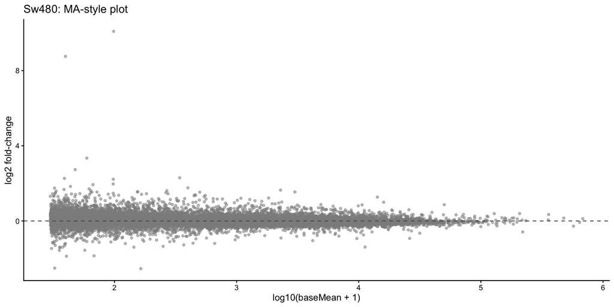

#### Volcano plot

This volcano plot compares log2 fold-change on the x-axis with statistical evidence on the y-axis. Genes farther from zero have larger effects and genes higher on the plot have stronger evidence; colour identifies genes passing the configured candidate thresholds.

[interactive chart not shown]

#### PCA

These context-specific PCA views summarise variance-stabilised gene expression across the samples used in this DESeq2 contrast. Use them to confirm sample structure and inspect whether major variance axes align with experimental metadata.

##### Scores

This selectable two-dimensional PCA score plot places samples according to the chosen components. Nearby samples have more similar expression profiles.

[interactive chart not shown]

##### Scree plot

This scree plot reports the variance explained by each principal component. The highest bars indicate the components carrying the largest expression differences between samples.

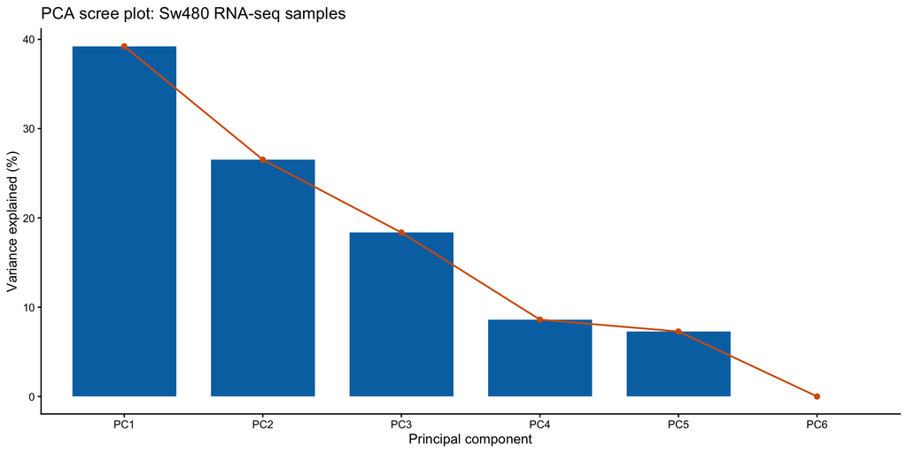

##### Metadata associations

This heatmap reports exploratory associations between PCA components and sample metadata. It should be used to guide interpretation and possible follow-up modelling, not as a standalone inferential result.

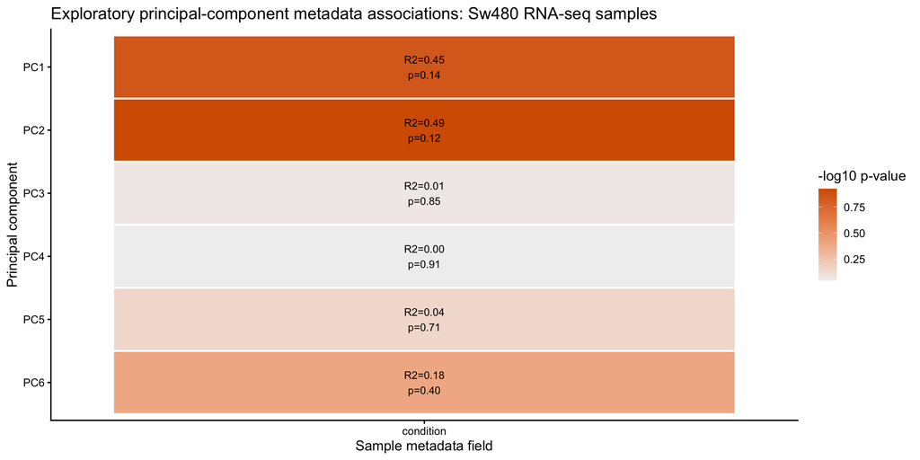

#### Heatmap by adjusted p-value

This heatmap displays up to 50 genes with the smallest adjusted p-values using variance-stabilised expression values. Rows are genes and columns are samples; clustering highlights expression patterns among the statistically strongest candidates.

[interactive chart not shown]

#### Heatmap by absolute log2 fold-change

This heatmap displays up to 50 genes with the largest absolute log2 fold-changes using variance-stabilised expression values. It emphasises the strongest effect sizes, which may differ from the genes with the smallest adjusted p-values.

[interactive chart not shown]

## Analysis information

This section documents how the analysis was performed and what files were used or generated. It is intended to support reproducibility and interpretation.

### Methods

This tab provides a publication-style description of the computational methods used in this report. It includes the analytical framework, thresholds, software, data resources and interpretation guidance.

#### Analytical framework

This report provides the primary RNA-seq quality-assessment and differential-expression layer. It uses DESeq2-based RNA-seq differential expression [1], variance-stabilising transformation and PCA for sample-level assessment [1], and stable CSV/TSV exports for reusable secondary modules.

Functional enrichment, network integration and TCGA validation are intentionally handled by separate modules that consume the standardized primary-analysis exports.

#### RNA-seq preprocessing and sample assessment

Gene-level count data were imported from the Salmon merged count table /Users/tomgiles/Desktop/Canserv2/Downstream_analysis/Inputs/salmon.merged.gene_counts.tsv. Samples, contexts and reference/comparison roles were selected from `Inputs/experimental_samplesheet.tsv`. Low-count genes were retained if they had at least 5 counts in at least 2 samples.

Variance-stabilised expression values were generated with DESeq2 and used for heatmap visualisation and two-dimensional PCA score plots [1]. The PCA score plots provide a selectable component-pair view for the first six available principal components. Separate scree plots report the variance explained by each component. Exploratory metadata-association heatmaps fit one-way linear models between the displayed principal components and available sample metadata fields, and report nominal p-values and R-squared values. The pairwise PCA views use all retained genes shared by the two context-specific count matrices; they are not restricted to DE candidates. Sample-level quality metrics included library size, RNA-type composition, housekeeping gene percentage and the percentage of genes expressed above 10 counts. RNA-type composition was summarised as a stacked percentage bar chart using mutually exclusive mitochondrial RNA, ribosomal RNA, tRNA, miRNA, snoRNA, snRNA, other small non-coding RNA, pseudogene, mRNA, lncRNA and other-RNA categories. Gene annotation for these categories was requested from Ensembl BioMart version 115 where available. Missing biotypes are filled from a cached official Ensembl release-115 GTF, with local Bioconductor annotation used as an additional fallback [2,3,6].

The housekeeping expression metric uses the Human Protein Atlas RNA tissue-distribution category `Detected in all`, downloaded through the documented Human Protein Atlas search-download API and cached locally for reproducible repeat renders [5]. If the API is temporarily unavailable, an existing cache is reused; the legacy local housekeeping file is retained only as an offline fallback.

#### Differential expression

Differential expression was performed independently for each manifest-defined RNA-seq context using DESeq2 [1], with the model `~ condition` and the configured comparison-versus-reference contrast. The downstream DE candidate exports use the global adjusted p-value threshold of 0.05 and absolute log2 fold-change greater than 0. Direction is assigned from the sign of the log2 fold-change. For every pair of configured contexts, a consensus candidate export and overlap diagram are generated automatically.

#### Software and data resources

The analysis was implemented in R using DESeq2 1.46.0, org.Hs.eg.db 3.20.0, biomaRt 2.62.1, plotly 4.12.0, heatmaply 1.6.0, dplyr 1.2.0, readr 2.2.0, tidyr 1.3.2, ggplot2 4.0.2, rmarkdown 2.30 and htmltools 0.5.9. The main data resources used were the Salmon merged gene-count table, the experimental samplesheet, the cached Human Protein Atlas housekeeping-gene list, Ensembl BioMart, the cached Ensembl GTF and local Bioconductor annotation.

#### References

[1] Love, M.I., Huber, W. and Anders, S. (2014) ‘Moderated estimation of fold change and dispersion for RNA-seq data with DESeq2’, *Genome Biology*, 15(12), 550. doi:10.1186/s13059-014-0550-8.

[2] Durinck, S., Spellman, P.T., Birney, E. and Huber, W. (2009) ‘Mapping identifiers for the integration of genomic datasets with the R/Bioconductor package biomaRt’, *Nature Protocols*, 4(8), pp. 1184-1191. doi:10.1038/nprot.2009.97.

[3] Huber, W., Carey, V.J., Gentleman, R., Anders, S., Carlson, M., Carvalho, B.S., Bravo, H.C., Davis, S., Gatto, L., Girke, T. et al. (2015) ‘Orchestrating high-throughput genomic analysis with Bioconductor’, *Nature Methods*, 12(2), pp. 115-121. doi:10.1038/nmeth.3252.

[4] Wickham, H., Averick, M., Bryan, J., Chang, W., McGowan, L.D., François, R., Grolemund, G., Hayes, A., Henry, L., Hester, J. et al. (2019) ‘Welcome to the tidyverse’, *Journal of Open Source Software*, 4(43), 1686. doi:10.21105/joss.01686.

[5] Human Protein Atlas. ‘The housekeeping proteome’ and documented programmatic data access. Available at: https://www.proteinatlas.org/humanproteome/tissue/housekeeping and https://www.proteinatlas.org/about/help/dataaccess.

[6] Ensembl. Human GRCh38 gene annotation in GTF format, release 115. Available at: https://ftp.ensembl.org/pub/release-115/gtf/homo_sapiens/.

### Files

This tab lists input data and report output files with descriptions, file statistics and links where possible.

| Role | File | Description | Exists | Rows | Columns | Size (KB) |
| --- | --- | --- | --- | --- | --- | --- |
| Input | salmon.merged.gene_counts.tsv | Salmon merged gene-count table used for DESeq2 and sample QC | TRUE | 78457 | 14 | 5161.4 |
| Input | hpa_housekeeping_genes.tsv | Cached Human Protein Atlas housekeeping gene list used for housekeeping expression QC | TRUE | 8813 | 3 | 347.4 |
| Input | Homo_sapiens.GRCh38.115.gtf.gz | Cached Ensembl release-115 GTF used to fill RNA-biotype annotations for sample composition | TRUE |  |  | 101948.8 |
| Input | experimental_samplesheet.tsv | Experimental samplesheet defining RNA-seq samples and contrasts | TRUE | 28 | 14 | 4.3 |
| Output | rnaseq_de_results__HT29_shp53_vs_scr.csv | HT29 DESeq2 results | TRUE | 15490 | 9 | 2332.8 |
| Output | rnaseq_de_results__Sw480_shp53_vs_scr.csv | Sw480 DESeq2 results | TRUE | 17459 | 9 | 2637.2 |
| Output | rnaseq_de_results__HT29_shp53_vs_scr.tsv | Standardized HT29 DESeq2 results for reusable downstream modules | TRUE | 15490 | 9 | 2332.8 |
| Output | rnaseq_de_results__Sw480_shp53_vs_scr.tsv | Standardized Sw480 DESeq2 results for reusable downstream modules | TRUE | 17459 | 9 | 2637.2 |
| Output | rnaseq_de_candidates__HT29_shp53_vs_scr.csv | HT29 DE candidate genes | TRUE | 3480 | 12 | 789.8 |
| Output | rnaseq_de_candidates__Sw480_shp53_vs_scr.csv | Sw480 DE candidate genes | TRUE | 855 | 12 | 195 |
| Output | rnaseq_de_consensus__HT29_shp53_vs_scr__Sw480_shp53_vs_scr.csv | HT29 / Sw480 pairwise consensus DE candidate genes | TRUE | 238 | 24 | 109.6 |
| Output | sample_qc_metrics.csv | Sample QC metrics | TRUE | 12 | 8 | 0.9 |
| Output | sample_rna_composition.csv | Sample RNA-type composition | TRUE | 120 | 5 | 6.8 |
| Output | analysis_thresholds.csv | Analysis thresholds | TRUE | 6 | 2 | 0.2 |
| Output | file_inventory.csv | Input/output file inventory | TRUE | 15 | 7 | 2.7 |

### Session notes

This tab records the R session information, including package versions. It is included to support reproducibility and troubleshooting.

[session information not shown]